# PA1_template

Azmanvai

December 8, 2017

### Loading and preprocessing the data

Show any code that is needed to

1. Load the data (i.e. read.csv())
2. Process/transform the data (if necessary) into a format suitable for your analysis

```r
activity <- read.csv("activity.csv")
activity$date <- as.Date(activity$date, "%Y-%m-%d")
```

### What is mean total number of steps taken per day?

For this part of the assignment, you can ignore the missing values in the dataset

1. Calculate the total number of steps taken per day

```r
stepday <- aggregate(steps ~ date, data = activity, sum, na.rm = TRUE)
```

2. Make a histogram of the total number of steps taken each day

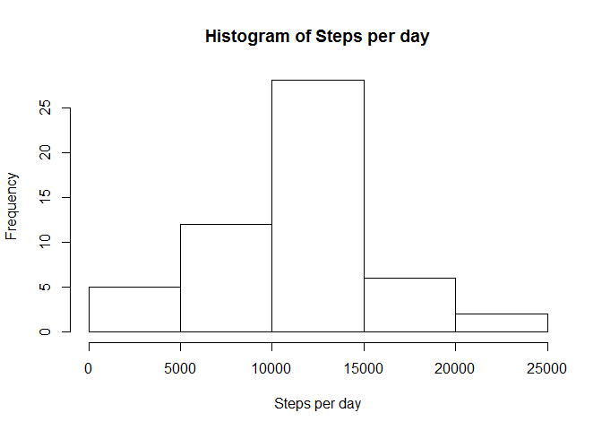

```r
hist(stepday$steps, freq = TRUE, xlab = "Steps per day", main = "Histogram of Steps per day")
```

3. Calculate and report the mean and median of the total number of steps taken per day

```r
average <- mean(stepday$steps)
med <- median(stepday$steps)
print(average)
```

```
## [1] 10766.19
```

```r
print(med)
```

```
## [1] 10765
```

### What is the average daily activity pattern?

1. Make a time series plot (i.e. type = “l”) of the 5-minute interval (x-axis) and the average number of steps taken, averaged across all days (y-axis)

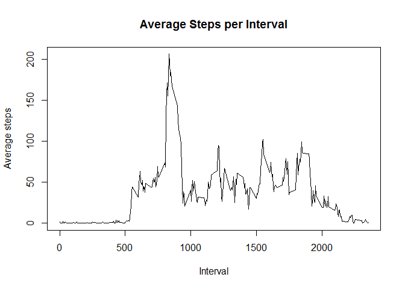

```r
avgstepint <- aggregate(steps ~ interval, data = activity, mean, na.rm = TRUE)
with(avgstepint, plot(interval, steps, type = "l", xlab = "Interval", ylab = "Average steps", main = "Average Steps per Interval"))
```

2. Which 5-minute interval, on average across all the days in the dataset, contains the maximum number of steps?

```r
maxstep <- with(avgstepint, interval[steps == max(steps)])
print(maxstep)
```

```
## [1] 835
```